# 2.4 Exercise Answers

Zou Junzhe

2024-07-09

# Conceptual

## Q1

For each of parts (a) through (d), indicate whether we would generally expect the performance of a flexible statistical learning method to be better or worse than an inflexible method. Justify your answer.

1. *The sample size n is extremely large, and the number of predictors p is small.*

Answer: flexible learning method would perform **better** because sample size is large enough to fit more parameters and small number of predictors limits model variance.

Explain:The more parameters you want to fit, the larger your sample size needs to be. So it’s possible to fit more parameters especially your sample size is far more larger than your predictors which means more flexibility.

2. *The number of predictors p is extremely large, and the number of observations n is small.*

Answer: flexible method would perform **worse** because it would be more likely to overfit.

Explain: the ratio of predictors and sample size is big. The felxible method with more parameters may have really high weight on every single observation of the very few samples. If there is an anomalous data point, the model would perform extremely bad.

3. *The relationship between the predictors and response is highly non-linear.*

Answer:flexible learning method would perform **better** because it is less restrictive on the shape of fit

4. *The variance of the error terms, i.e. σ2 = Var(ε), is extremely high.*

Answer: flexible learning method would perform **worse** because it would be more likely to overfit.

Explain: high $\epsilon$ means that the data point is more likely to be anomalous.

Notes: MSE evaluates a model. And MSE contains Variance and Bias. Variance indicates how significantly the model would change with a change of training data set. Bias is more like the difference between the estimate value and real value. A more flexible model( a curve passes through every single training observation) usually has low bias but high variance. Because you change one point your model change with the point and that’s variance. A more inflexible model( a horizontal line) has low variance but higher bias. The horizontal model barely passes through any observation which indicates high bias but also indicates that the variance would be low.

## Q2

Explain whether each scenario is a classification or regression prob- lem, and indicate whether we are most interested in inference or prediction. Finally, provide n and p.

1. *We collect a set of data on the top 500 firms in the US. For each firm we record profit, number of employees, industry and the CEO salary. We are interested in understanding which factors affect CEO salary.*

Answer:

- regression
- inference
- observations: n = 500
- predictors: p = 3 (profit,number of employees, industry)
2. *We are considering launching a new product and wish to know whether it will be a success or a failure. We collect data on 20 similar products that were previously launched. For each product we have recorded whether it was a success or failure, price charged for the product, marketing budget, competition price, and ten other variables.*

Answer:

- classification
- prediction
- observations: n = 20
- predictors: p = 13 (price charged for the product, marketing budget, competition price, and ten other variables)
3. *We are interesting in predicting the % change in the US dollar in relation to the weekly changes in the world stock markets. Hence we collect weekly data for all of 2012. For each week we record the % change in the dollar, the % change in the US market, the % change in the British market, and the % change in the German market.*

Answer:

Notes:

> We tend to refer to problems with a quantitative response as regression problems, while those involving a qualitative response are often referred to as classification problems.

## Q3

We now revisit the bias-variance decomposition.

1. *Provide a sketch of typical (squared) bias, variance, training error, test error, and Bayes (or irreducible) error curves, on a single plot, as we go from less flexible statistical learning methods towards more flexible approaches. The x-axis should represent the amount of flexibility in the method, and the y-axis should represent the values for each curve. There should be five curves. Make sure to label each one.*

2. *Explain why each of the five curves has the shape displayed in part (a).*

Answer:

- train error: train error will continuously decreases to zero with increasing amount of flexibility.
- test error: At first, test error decrease because a larger amount of flexibility makes the model fits better. But at some point, the problem of overfitting starts to have a role, which makes test error start to increase.
- variance: it continuously increases with flexibility because of its definition.
- irreducible error: irreducible error doesn’t relates to the flexibility.
- bias: bias is kind of similar to training error. It continuously decreases as flexibility increases.

## Q4

You will now think of some real-life applications for statistical learning.

1. *Describe three real-life applications in which classification might be useful. Describe the response, as well as the predictors. Is the goal of each application inference or prediction? Explain your answer.*

Answer:

- 1
- University application.
- responses: admit or reject
- predictors: GPA, Internship, Academic research
- prediction
- 2
- Client classification
- responses : VIP, Members, Ordinary
- predictors : monthly consumption, family reputation, Occupation
2. *Describe three real-life applications in which regression might be useful. Describe the response, as well as the predictors. Is the goal of each application inference or prediction? Explain your answer.*
- 1
- store’s sales
- response: a store’s sales
- predictors: location, customer traffic, opening hours
- prediction
- 2
- salary
- response: salary
- predictors: job title, length of service, education
- prediction
3. Describe three real-life applications in which cluster analysis might be useful.
- 1
- type of residents
- type of cancer cells

Note: There’s one point that clustering clusters the original data set but classification makes predictions. Classification is supervised learning and clustering is unsupervised. Cluster analysis results in clusters of observations without predefined labels.

## Q5

What are the advantages and disadvantages of a very flexible (versus a less flexible) approach for regression or classification? Under what circumstances might a more flexible approach be preferred to a less flexible approach? When might a less flexible approach be preferred?

Answer:

For a very flexible approach:

- advantages: better fits the data; fewer assumptions
- disadvantages: hard to interpret; overfitting

Circumstances for flexible approach: the data itself is so complex that it needs more parameters; we care about the prediction instead of inference.

Circumstances for less flexible approaches: the data is simple and it attaches importance to inference.

## Q6

Describe the differences between a parametric and a non-parametric statistical learning approach. What are the advantages of a para- metric approach to regression or classification (as opposed to a non- parametric approach)? What are its disadvantages?

Answer:

- the difference: parametric statistical learning makes assumptions on the shape of the model but non-parametric approach makes no assumptions on that.
- parametric approach’s advantages and disadvantages: parametric approach needs less data by making assumptions on the shape of the model, which turns out to be a disadvantage that the assumption may be wrong at first. Non-parametric approach requires more data but avoids the possible mistake of making wrong assumptions.

## Q7

1. *Compute the Euclidean distance between each observation and the test point,X1 =X2 =X3 =0.*

Answer:

```r
ob0 = c(0,0,0)
ob1 = c(0,3,0)
ob2 = c(2,0,0)
ob3 = c(0,1,3)
ob4 = c(0,1,2)
ob5 = c(-1,0,1)
ob6 = c(1,1,1)

dist1 = sqrt(sum((ob1 - ob0)^2))
dist2 = sqrt(sum((ob2 - ob0)^2))
dist3 = sqrt(sum((ob3 - ob0)^2))
dist4 = sqrt(sum((ob4 - ob0)^2))
dist5 = sqrt(sum((ob5 - ob0)^2))
dist6 = sqrt(sum((ob6 - ob0)^2))

print(paste(dist1,dist2,dist3,dist4,dist5,dist6))
```

```
## [1] "3 2 3.16227766016838 2.23606797749979 1.4142135623731 1.73205080756888"
```

2. *What is our prediction with K = 1? Why?*

Answer:

K=1 then include ob5(Green). So prediction = **Green**

3. *What is our prediction with K = 3? Why?*

Answer:

K=3, then include ob5(Green), ob6(Red) and ob2(Red). So prediction = **Red**.

4. *If the Bayes decision boundary in this problem is highly non-linear, then would we expect the best value for K to be large or small? Why?*

Answer:

We expect K to be smaller to capture the non-linear part of the boundary.

Note: If K is big, the KNN boundary may be flat and ignore the irregularity on the edge. Just like the example of K = 1 and K = 100 in the main part.

# Applied

## Q8

1. *Use the read.csv() function to read the data into R. Call the loaded data college. Make sure that you have the directory set to the correct location for the data.*

you can download the data set here: https://www.statlearning.com/resources-second-edition

```r
college = read.csv("College.csv")
str(college)
```

```
## 'data.frame':    777 obs. of  19 variables:
##  $ X          : chr  "Abilene Christian University" "Adelphi University" "Adrian College" "Agnes Scott College" ...
##  $ Private    : chr  "Yes" "Yes" "Yes" "Yes" ...
##  $ Apps       : int  1660 2186 1428 417 193 587 353 1899 1038 582 ...
##  $ Accept     : int  1232 1924 1097 349 146 479 340 1720 839 498 ...
##  $ Enroll     : int  721 512 336 137 55 158 103 489 227 172 ...
##  $ Top10perc  : int  23 16 22 60 16 38 17 37 30 21 ...
##  $ Top25perc  : int  52 29 50 89 44 62 45 68 63 44 ...
##  $ F.Undergrad: int  2885 2683 1036 510 249 678 416 1594 973 799 ...
##  $ P.Undergrad: int  537 1227 99 63 869 41 230 32 306 78 ...
##  $ Outstate   : int  7440 12280 11250 12960 7560 13500 13290 13868 15595 10468 ...
##  $ Room.Board : int  3300 6450 3750 5450 4120 3335 5720 4826 4400 3380 ...
##  $ Books      : int  450 750 400 450 800 500 500 450 300 660 ...
##  $ Personal   : int  2200 1500 1165 875 1500 675 1500 850 500 1800 ...
##  $ PhD        : int  70 29 53 92 76 67 90 89 79 40 ...
##  $ Terminal   : int  78 30 66 97 72 73 93 100 84 41 ...
##  $ S.F.Ratio  : num  18.1 12.2 12.9 7.7 11.9 9.4 11.5 13.7 11.3 11.5 ...
##  $ perc.alumni: int  12 16 30 37 2 11 26 37 23 15 ...
##  $ Expend     : int  7041 10527 8735 19016 10922 9727 8861 11487 11644 8991 ...
##  $ Grad.Rate  : int  60 56 54 59 15 55 63 73 80 52 ...
```

```r
library(ISLR2)
data(College)
head(College)
```

|  | Private | Apps | Accept | Enroll | Top10perc | Top25perc | F.Undergrad | P.Undergrad | Outstate | Room.Board | Books | Personal | PhD | Terminal | S.F.Ratio | perc.alumni | Expend | Grad.Rate |
| --- | --- | --- | --- | --- | --- | --- | --- | --- | --- | --- | --- | --- | --- | --- | --- | --- | --- | --- |
| Abilene Christian University | Yes | 1660 | 1232 | 721 | 23 | 52 | 2885 | 537 | 7440 | 3300 | 450 | 2200 | 70 | 78 | 18.1 | 12 | 7041 | 60 |
| Adelphi University | Yes | 2186 | 1924 | 512 | 16 | 29 | 2683 | 1227 | 12280 | 6450 | 750 | 1500 | 29 | 30 | 12.2 | 16 | 10527 | 56 |
| Adrian College | Yes | 1428 | 1097 | 336 | 22 | 50 | 1036 | 99 | 11250 | 3750 | 400 | 1165 | 53 | 66 | 12.9 | 30 | 8735 | 54 |
| Agnes Scott College | Yes | 417 | 349 | 137 | 60 | 89 | 510 | 63 | 12960 | 5450 | 450 | 875 | 92 | 97 | 7.7 | 37 | 19016 | 59 |
| Alaska Pacific University | Yes | 193 | 146 | 55 | 16 | 44 | 249 | 869 | 7560 | 4120 | 800 | 1500 | 76 | 72 | 11.9 | 2 | 10922 | 15 |
| Albertson College | Yes | 587 | 479 | 158 | 38 | 62 | 678 | 41 | 13500 | 3335 | 500 | 675 | 67 | 73 | 9.4 | 11 | 9727 | 55 |

2. *Look at the data using the fix() function.*

the code explains how to make the first column a “row.names” “column” which is not in the data set

```r
head(rownames(college)) # original row names of the data is the order number
```

```
## [1] "1" "2" "3" "4" "5" "6"
```

```r
rownames(college)=college[,1] # we use the first column's value to be the "college"'s row names
#fix(college) #there's an identical column named "row.names" to the first column in the original data set
```

```r
college=college[,-1]
#fix(college) # you can see that the "row.names" column didn't get removed
```

1. *Use the summary() function to produce a numerical summary of the variables in the data set.*

```r
summary(college)
```

```
##    Private               Apps           Accept          Enroll
##  Length:777         Min.   :   81   Min.   :   72   Min.   :  35
##  Class :character   1st Qu.:  776   1st Qu.:  604   1st Qu.: 242
##  Mode  :character   Median : 1558   Median : 1110   Median : 434
##                     Mean   : 3002   Mean   : 2019   Mean   : 780
##                     3rd Qu.: 3624   3rd Qu.: 2424   3rd Qu.: 902
##                     Max.   :48094   Max.   :26330   Max.   :6392
##    Top10perc       Top25perc      F.Undergrad     P.Undergrad
##  Min.   : 1.00   Min.   :  9.0   Min.   :  139   Min.   :    1.0
##  1st Qu.:15.00   1st Qu.: 41.0   1st Qu.:  992   1st Qu.:   95.0
##  Median :23.00   Median : 54.0   Median : 1707   Median :  353.0
##  Mean   :27.56   Mean   : 55.8   Mean   : 3700   Mean   :  855.3
##  3rd Qu.:35.00   3rd Qu.: 69.0   3rd Qu.: 4005   3rd Qu.:  967.0
##  Max.   :96.00   Max.   :100.0   Max.   :31643   Max.   :21836.0
##     Outstate       Room.Board       Books           Personal
##  Min.   : 2340   Min.   :1780   Min.   :  96.0   Min.   : 250
##  1st Qu.: 7320   1st Qu.:3597   1st Qu.: 470.0   1st Qu.: 850
##  Median : 9990   Median :4200   Median : 500.0   Median :1200
##  Mean   :10441   Mean   :4358   Mean   : 549.4   Mean   :1341
##  3rd Qu.:12925   3rd Qu.:5050   3rd Qu.: 600.0   3rd Qu.:1700
##  Max.   :21700   Max.   :8124   Max.   :2340.0   Max.   :6800
##       PhD            Terminal       S.F.Ratio      perc.alumni
##  Min.   :  8.00   Min.   : 24.0   Min.   : 2.50   Min.   : 0.00
##  1st Qu.: 62.00   1st Qu.: 71.0   1st Qu.:11.50   1st Qu.:13.00
##  Median : 75.00   Median : 82.0   Median :13.60   Median :21.00
##  Mean   : 72.66   Mean   : 79.7   Mean   :14.09   Mean   :22.74
##  3rd Qu.: 85.00   3rd Qu.: 92.0   3rd Qu.:16.50   3rd Qu.:31.00
##  Max.   :103.00   Max.   :100.0   Max.   :39.80   Max.   :64.00
##      Expend        Grad.Rate
##  Min.   : 3186   Min.   : 10.00
##  1st Qu.: 6751   1st Qu.: 53.00
##  Median : 8377   Median : 65.00
##  Mean   : 9660   Mean   : 65.46
##  3rd Qu.:10830   3rd Qu.: 78.00
##  Max.   :56233   Max.   :118.00
```

2. *Use the pairs() function to produce a scatterplot matrix of the first ten columns or variables of the data. Recall that you can reference the first ten columns of a matrix A using A[,1:10].*

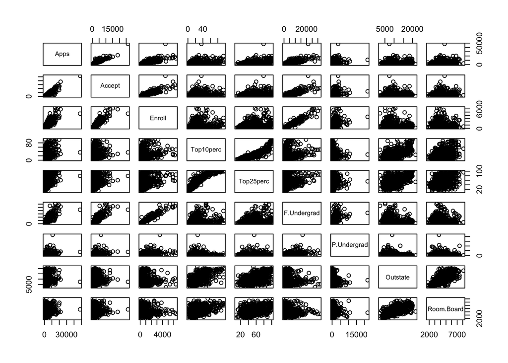

```r
pairs(college[,2:10]) # the first column "Private" is not numeric
```

3. *Use the plot() function to produce side-by-side boxplots of Outstate versus Private.*

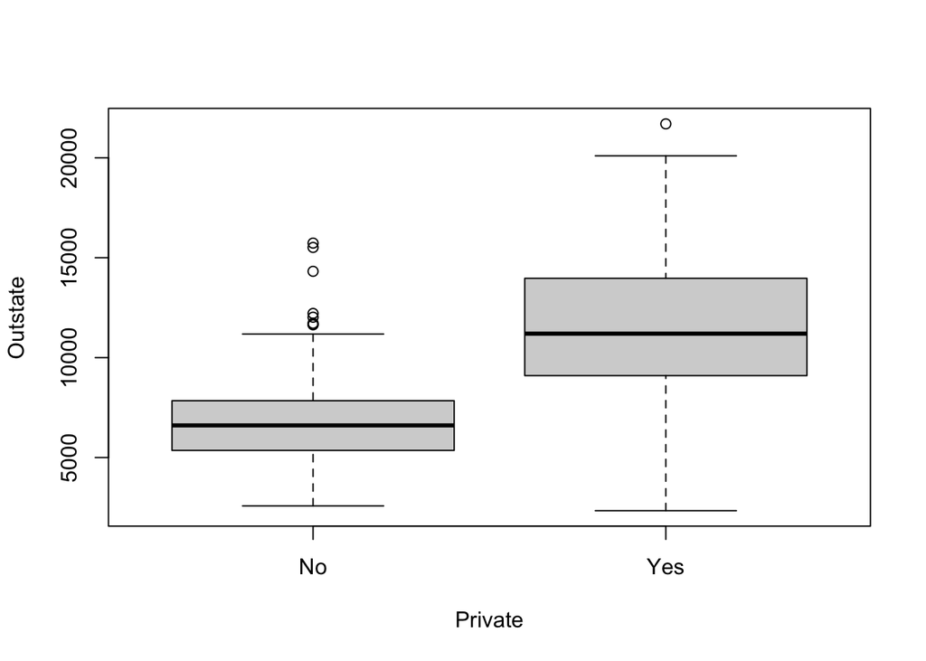

```r
boxplot(college$Outstate~college$Private,xlab = "Private", ylab = "Outstate")
```

4. *Create a new qualitative variable, called Elite, by binning the Top10perc variable. We are going to divide universities into two groups based on whether or not the proportion of students coming from the top 10% of their high school classes exceeds 50%.*

```r
Elite = rep("No", nrow(college)) # you first create a all "No" vector with the same length as college's rows
Elite[college$Top10perc > 50] = "Yes" #Then you change the label for those whose Top10perc > 50
Elite = as.factor(Elite) #Change to qualitative variable
college = data.frame(college,Elite) #bind the new variable into the data frame
```

```r
summary(Elite)
```

```
##  No Yes
## 699  78
```

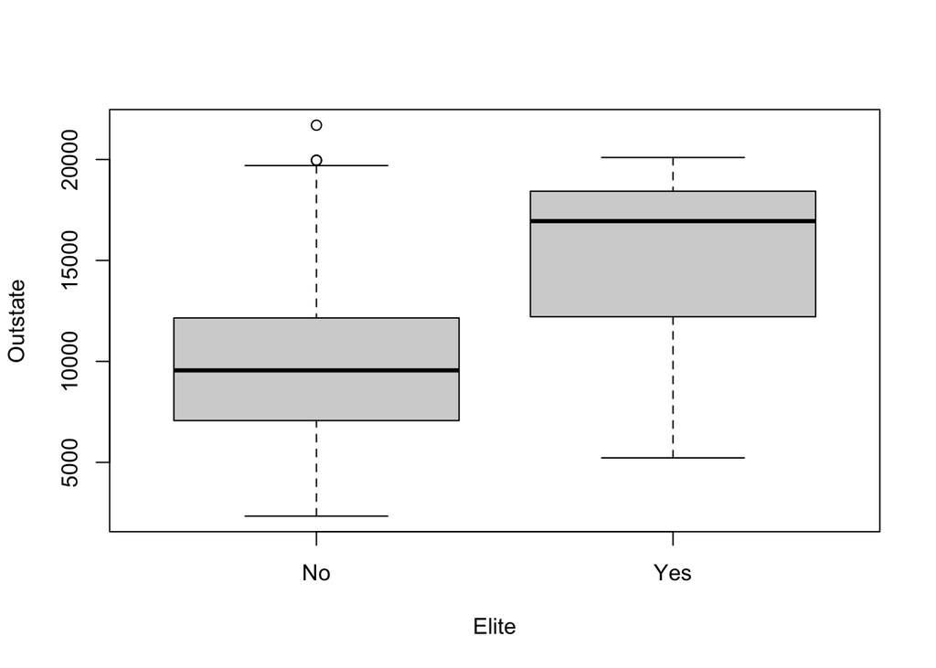

```r
plot(Outstate ~ Elite,data = college, xlab = "Elite", ylab = "Outstate")
```

Note:

*Elite[college$Top10perc > 50] = “Yes”* is a conditional value change sentence(forgive my poor English). *college$Top10perc > 50 will return a TRUE and FALSE sequence indicates the corresponding position to make the change or not. If “TRUE”, the same position of* ELite* will be changed into Yes.

22. *Use the hist() function to produce some histograms with differing numbers of bins for a few of the quantitative variables. You may find the command par(mfrow=c(2,2)) useful: it will divide the print window into four regions so that four plots can be made simultaneously. Modifying the arguments to this function will divide the screen in other ways.*

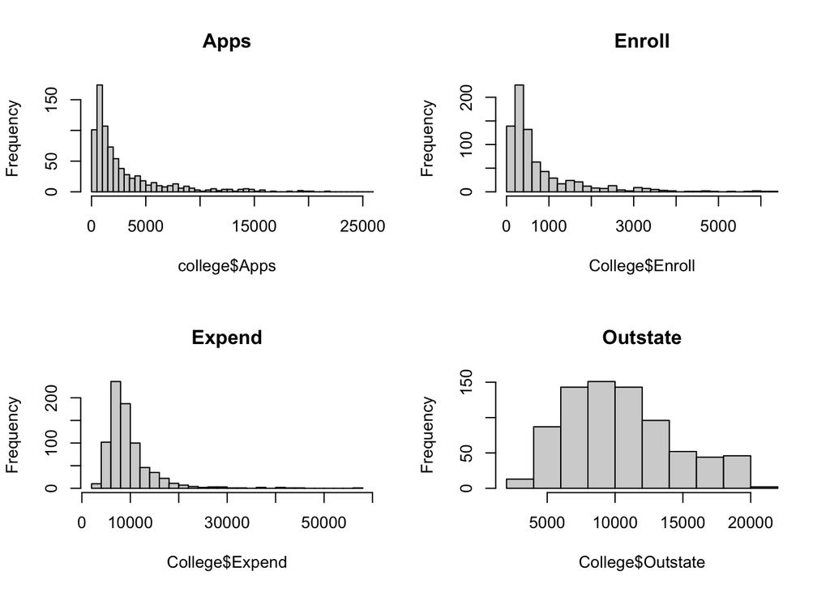

```r
par(mfrow=c(2,2))
hist(college$Apps, breaks=100,xlim = c(0,25000), main="Apps")
hist(College$Enroll, breaks=25, main="Enroll")
hist(College$Expend, breaks=25, main="Expend")
hist(College$Outstate, main="Outstate")
```

## Q9

```r
auto = Auto
auto = na.omit(auto) #remove the missing values
```

1. *Which of the predictors are quantitative, and which are qualitative?*

```r
str(auto)
```

```
## 'data.frame':    392 obs. of  9 variables:
##  $ mpg         : num  18 15 18 16 17 15 14 14 14 15 ...
##  $ cylinders   : int  8 8 8 8 8 8 8 8 8 8 ...
##  $ displacement: num  307 350 318 304 302 429 454 440 455 390 ...
##  $ horsepower  : int  130 165 150 150 140 198 220 215 225 190 ...
##  $ weight      : int  3504 3693 3436 3433 3449 4341 4354 4312 4425 3850 ...
##  $ acceleration: num  12 11.5 11 12 10.5 10 9 8.5 10 8.5 ...
##  $ year        : int  70 70 70 70 70 70 70 70 70 70 ...
##  $ origin      : int  1 1 1 1 1 1 1 1 1 1 ...
##  $ name        : Factor w/ 304 levels "amc ambassador brougham",..: 49 36 231 14 161 141 54 223 241 2 ...
##  - attr(*, "na.action")= 'omit' Named int [1:5] 33 127 331 337 355
##   ..- attr(*, "names")= chr [1:5] "33" "127" "331" "337" ...
```

```r
summary(auto)
```

```
##       mpg          cylinders      displacement     horsepower        weight
##  Min.   : 9.00   Min.   :3.000   Min.   : 68.0   Min.   : 46.0   Min.   :1613
##  1st Qu.:17.00   1st Qu.:4.000   1st Qu.:105.0   1st Qu.: 75.0   1st Qu.:2225
##  Median :22.75   Median :4.000   Median :151.0   Median : 93.5   Median :2804
##  Mean   :23.45   Mean   :5.472   Mean   :194.4   Mean   :104.5   Mean   :2978
##  3rd Qu.:29.00   3rd Qu.:8.000   3rd Qu.:275.8   3rd Qu.:126.0   3rd Qu.:3615
##  Max.   :46.60   Max.   :8.000   Max.   :455.0   Max.   :230.0   Max.   :5140
##
##   acceleration        year           origin                      name
##  Min.   : 8.00   Min.   :70.00   Min.   :1.000   amc matador       :  5
##  1st Qu.:13.78   1st Qu.:73.00   1st Qu.:1.000   ford pinto        :  5
##  Median :15.50   Median :76.00   Median :1.000   toyota corolla    :  5
##  Mean   :15.54   Mean   :75.98   Mean   :1.577   amc gremlin       :  4
##  3rd Qu.:17.02   3rd Qu.:79.00   3rd Qu.:2.000   amc hornet        :  4
##  Max.   :24.80   Max.   :82.00   Max.   :3.000   chevrolet chevette:  4
##                                                  (Other)           :365
```

quantitative: mpg, displacement, horsepower, weight, acceleration, year

qualitative: cylinder, origin, name

2. *What is the range of each quantitative predictor? You can answer this using the range() function.*

```r
range(auto$mpg)
```

```
## [1]  9.0 46.6
```

```r
range(auto$displacement)
```

```
## [1]  68 455
```

```r
range(auto$horsepower)
```

```
## [1]  46 230
```

```r
range(auto$weight)
```

```
## [1] 1613 5140
```

```r
range(auto$acceleration)
```

```
## [1]  8.0 24.8
```

```r
range(auto$year)
```

```
## [1] 70 82
```

3. *What is the mean and standard deviation of each quantitative predictor?*

```r
sapply(auto[,c(1,3,4,5,6,7)], mean)
```

```
##          mpg displacement   horsepower       weight acceleration         year
##     23.44592    194.41199    104.46939   2977.58418     15.54133     75.97959
```

```r
sapply(auto[,c(1,3,4,5,6,7)], sd)
```

```
##          mpg displacement   horsepower       weight acceleration         year
##     7.805007   104.644004    38.491160   849.402560     2.758864     3.683737
```

Note: sapply is a function to do a certain function on several list at one time and tries to simplify the result.

4. *Now remove the 10th through 85th observations. What is the range, mean, and standard deviation of each predictor in the subset of the data that remains?*

```r
tem = auto[,-(8:9)] # drop origin, name
less_auto = tem[-(10:85),] # remove the specified rows
sapply(less_auto[,c(1,3,4,5,6,7)],range)
```

```
##       mpg displacement horsepower weight acceleration year
## [1,] 11.0           68         46   1649          8.5   70
## [2,] 46.6          455        230   4997         24.8   82
```

```r
sapply(less_auto[,c(1,3,4,5,6,7)], mean)
```

```
##          mpg displacement   horsepower       weight acceleration         year
##     24.40443    187.24051    100.72152   2935.97152     15.72690     77.14557
```

```r
sapply(less_auto[,c(1,3,4,5,6,7)],sd)
```

```
##          mpg displacement   horsepower       weight acceleration         year
##     7.867283    99.678367    35.708853   811.300208     2.693721     3.106217
```

Note: when dropping multiple cols or rows, need “()” like [-(10:85),] and [-10:85,] is wrong.

5. *Using the full data set, investigate the predictors graphically, using scatterplots or other tools of your choice. Create some plots highlighting the relationships among the predictors. Comment on your findings.*

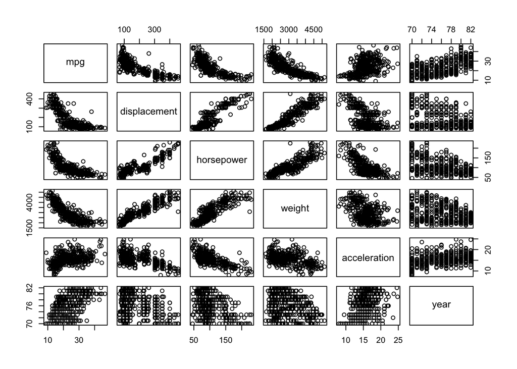

```r
pairs(auto[,c(1,3,4,5,6,7)])
```

eg: horsepower is increasing with weight.

6. *Suppose that we wish to predict gas mileage (mpg) on the basis of the other variables. Do your plots suggest that any of the other variables might be useful in predicting mpg? Justify your answer.*

eg: mpg may have a negative relation with horsepower.

## Q10

1. *To begin, load in the Boston data set. The Boston data set is part of the MASS library in R.*

```r
library(MASS)
?Boston
```

```
## Help on topic 'Boston' was found in the following packages:
##
##   Package               Library
##   ISLR2                 /Library/Frameworks/R.framework/Versions/4.3-arm64/Resources/library
##   MASS                  /Library/Frameworks/R.framework/Versions/4.3-arm64/Resources/library
##
##
## Using the first match ...
```

2. *Make some pairwise scatterplots of the predictors (columns) in this data set. Describe your findings.*

```r
str(Boston)
```

```
## 'data.frame':    506 obs. of  14 variables:
##  $ crim   : num  0.00632 0.02731 0.02729 0.03237 0.06905 ...
##  $ zn     : num  18 0 0 0 0 0 12.5 12.5 12.5 12.5 ...
##  $ indus  : num  2.31 7.07 7.07 2.18 2.18 2.18 7.87 7.87 7.87 7.87 ...
##  $ chas   : int  0 0 0 0 0 0 0 0 0 0 ...
##  $ nox    : num  0.538 0.469 0.469 0.458 0.458 0.458 0.524 0.524 0.524 0.524 ...
##  $ rm     : num  6.58 6.42 7.18 7 7.15 ...
##  $ age    : num  65.2 78.9 61.1 45.8 54.2 58.7 66.6 96.1 100 85.9 ...
##  $ dis    : num  4.09 4.97 4.97 6.06 6.06 ...
##  $ rad    : int  1 2 2 3 3 3 5 5 5 5 ...
##  $ tax    : num  296 242 242 222 222 222 311 311 311 311 ...
##  $ ptratio: num  15.3 17.8 17.8 18.7 18.7 18.7 15.2 15.2 15.2 15.2 ...
##  $ black  : num  397 397 393 395 397 ...
##  $ lstat  : num  4.98 9.14 4.03 2.94 5.33 ...
##  $ medv   : num  24 21.6 34.7 33.4 36.2 28.7 22.9 27.1 16.5 18.9 ...
```

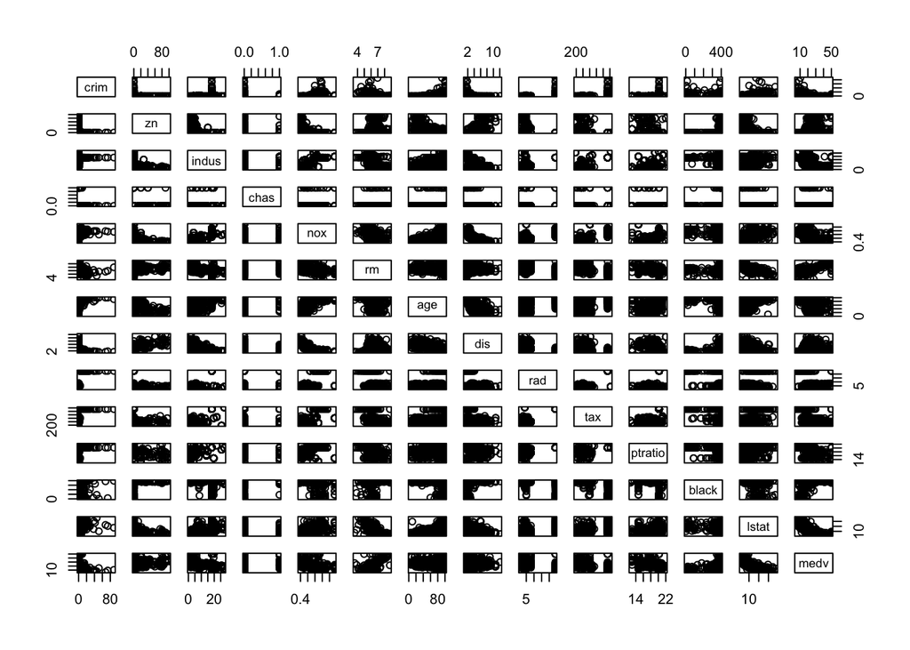

```r
pairs(Boston)
```

eg: age has a negative relation with dis. It may indicates that the employment centers may have more old buildings.

3. *Are any of the predictors associated with per capita crime rate? If so, explain the relationship.*

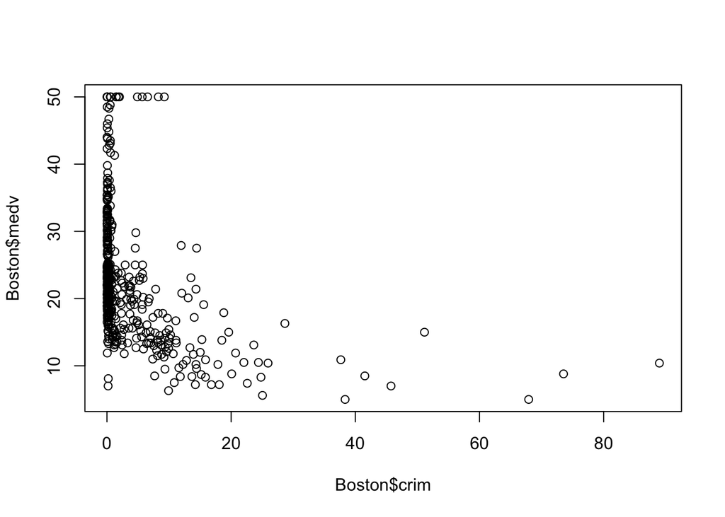

```r
plot(Boston$crim,Boston$medv)
```

eg: higher medv area has significantly low crim

4. *Do any of the suburbs of Boston appear to have particularly high crime rates? Tax rates? Pupil-teacher ratios? Comment on the range of each predictor.*

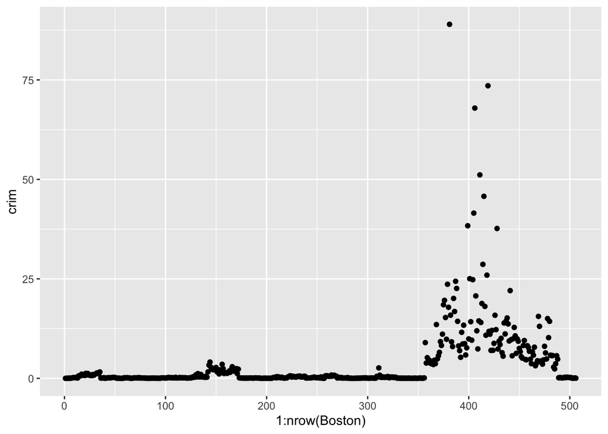

```r
require(ggplot2)
g <- ggplot(Boston, aes(x=1:nrow(Boston), y=crim))
g + geom_point()
```

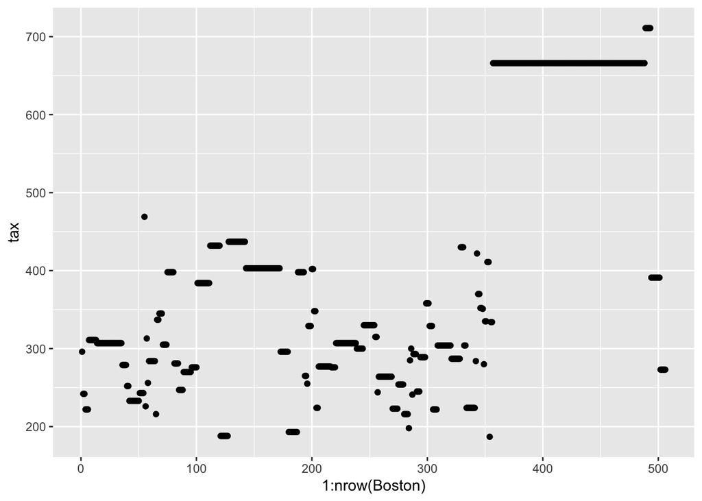

```r
g <- ggplot(Boston, aes(x=1:nrow(Boston), y=tax))
g + geom_point()
```

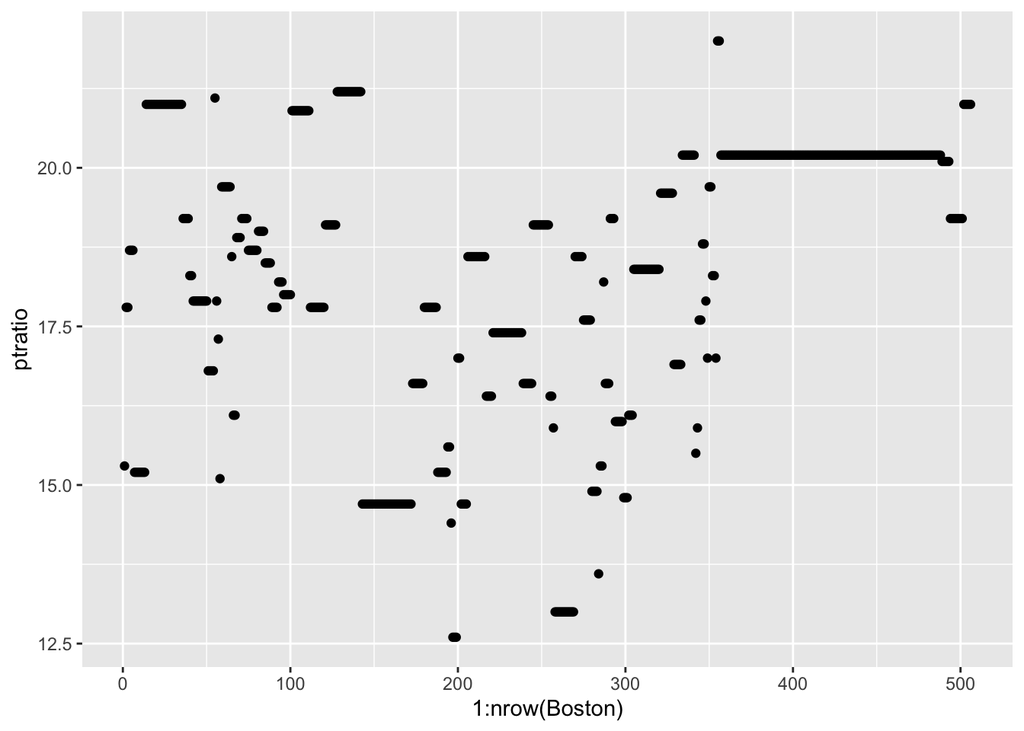

```r
g <- ggplot(Boston, aes(x=1:nrow(Boston), y=ptratio))
g + geom_point()
```

crime has outliers; tax has outliers; pupil-teacher ratio might have outliers.

5. *How many of the suburbs in this data set bound the Charles river?*

```r
sum(Boston$chas)
```

```
## [1] 35
```

```r
#chas
#Charles River dummy variable (= 1 if tract bounds river; 0 otherwise)
```

35 towns set bound the Charls river.

6. *What is the median pupil-teacher ratio among the towns in this data set?*

```r
median(Boston$ptratio)
```

```
## [1] 19.05
```

median ptratio is 19.05

7. *Which suburb of Boston has lowest median value of owner-occupied homes? What are the values of the other predictors for that suburb, and how do those values compare to the overall ranges for those predictors? Comment on your findings.*

```r
lowest <- Boston[Boston$medv == min(Boston$medv),] # find the lowest medv rows
lowest
```

|  | crim | zn | indus | chas | nox | rm | age | dis | rad | tax | ptratio | black | lstat | medv |
| --- | --- | --- | --- | --- | --- | --- | --- | --- | --- | --- | --- | --- | --- | --- |
| 399 | 38.3518 | 0 | 18.1 | 0 | 0.693 | 5.453 | 100 | 1.4896 | 24 | 666 | 20.2 | 396.90 | 30.59 | 5 |
| 406 | 67.9208 | 0 | 18.1 | 0 | 0.693 | 5.683 | 100 | 1.4254 | 24 | 666 | 20.2 | 384.97 | 22.98 | 5 |

```r
summary(Boston) # the overall ranges of predictors
```

```
##       crim                zn             indus            chas
##  Min.   : 0.00632   Min.   :  0.00   Min.   : 0.46   Min.   :0.00000
##  1st Qu.: 0.08205   1st Qu.:  0.00   1st Qu.: 5.19   1st Qu.:0.00000
##  Median : 0.25651   Median :  0.00   Median : 9.69   Median :0.00000
##  Mean   : 3.61352   Mean   : 11.36   Mean   :11.14   Mean   :0.06917
##  3rd Qu.: 3.67708   3rd Qu.: 12.50   3rd Qu.:18.10   3rd Qu.:0.00000
##  Max.   :88.97620   Max.   :100.00   Max.   :27.74   Max.   :1.00000
##       nox               rm             age              dis
##  Min.   :0.3850   Min.   :3.561   Min.   :  2.90   Min.   : 1.130
##  1st Qu.:0.4490   1st Qu.:5.886   1st Qu.: 45.02   1st Qu.: 2.100
##  Median :0.5380   Median :6.208   Median : 77.50   Median : 3.207
##  Mean   :0.5547   Mean   :6.285   Mean   : 68.57   Mean   : 3.795
##  3rd Qu.:0.6240   3rd Qu.:6.623   3rd Qu.: 94.08   3rd Qu.: 5.188
##  Max.   :0.8710   Max.   :8.780   Max.   :100.00   Max.   :12.127
##       rad              tax           ptratio          black
##  Min.   : 1.000   Min.   :187.0   Min.   :12.60   Min.   :  0.32
##  1st Qu.: 4.000   1st Qu.:279.0   1st Qu.:17.40   1st Qu.:375.38
##  Median : 5.000   Median :330.0   Median :19.05   Median :391.44
##  Mean   : 9.549   Mean   :408.2   Mean   :18.46   Mean   :356.67
##  3rd Qu.:24.000   3rd Qu.:666.0   3rd Qu.:20.20   3rd Qu.:396.23
##  Max.   :24.000   Max.   :711.0   Max.   :22.00   Max.   :396.90
##      lstat            medv
##  Min.   : 1.73   Min.   : 5.00
##  1st Qu.: 6.95   1st Qu.:17.02
##  Median :11.36   Median :21.20
##  Mean   :12.65   Mean   :22.53
##  3rd Qu.:16.95   3rd Qu.:25.00
##  Max.   :37.97   Max.   :50.00
```

findings: they have higher *crim* than other suburbs. their *age* and *rad* are the maximum level.

8. *In this data set, how many of the suburbs average more than seven rooms per dwelling? More than eight rooms per dwelling? Comment on the suburbs that average more than eight rooms per dwelling.*

```r
nrow(Boston[Boston$rm > 7,]) # number of dwellings with 7+ rooms
```

```
## [1] 64
```

```r
nrow(Boston[Boston$rm > 8,]) # number of dwellings with 8+ rooms
```

```
## [1] 13
```

64 has more than 7 rooms and 13 has more than 8 rooms.

```r
room_7 <- Boston[Boston$rm > 7 , ]
room_8 <- Boston[Boston$rm > 8 , ] # let them be a new data set
sapply(room_7, mean)
```

```
##        crim          zn       indus        chas         nox          rm
##   0.9791089  28.1718750   5.7756250   0.1250000   0.5044547   7.5700937
##         age         dis         rad         tax     ptratio       black
##  60.6406250   4.1996172   5.9843750 312.2343750  16.2593750 388.2751563
##       lstat        medv
##   5.4740625  38.3968750
```

```r
sapply(room_8, mean)
```

```
##        crim          zn       indus        chas         nox          rm
##   0.7187954  13.6153846   7.0784615   0.1538462   0.5392385   8.3485385
##         age         dis         rad         tax     ptratio       black
##  71.5384615   3.4301923   7.4615385 325.0769231  16.3615385 385.2107692
##       lstat        medv
##   4.3100000  44.2000000
```

```r
sapply(Boston[Boston$rm <= 7,],mean)
```

```
##         crim           zn        indus         chas          nox           rm
##   3.99497726   8.92986425  11.91305430   0.06108597   0.56196968   6.09850452
##          age          dis          rad          tax      ptratio        black
##  69.72375566   3.73646176  10.06561086 422.13800905  18.77352941 352.09830317
##        lstat         medv
##  13.69255656  20.23574661
```

```r
sapply(Boston[Boston$rm <= 8,],mean) # if you want to do a function to all the variables simultaneously, you use "sapply"
```

```
##         crim           zn        indus         chas          nox           rm
##   3.68985513  11.30425963  11.24379310   0.06693712   0.55510264   6.23021095
##          age          dis          rad          tax      ptratio        black
##  68.49675456   3.80466349   9.60446247 410.43002028  18.51075051 355.92154158
##        lstat         medv
##  12.87306288  21.96146045
```

eg: *crim* is significantly lower than others.